# Tree

Tree merupakan struktur data yang berbentuk non linear, Bentuk Tree di computer science hampir sama dengan tree yang terdapat pada ekosistem biologi, yaitu keduanya memiliki root, leaves, dan branches. Hanya saja, jika pada ekosistem biologi, akar terletak di bagian paling bawah dan daun ataupun batang terletak diatasnya.

Deskripsi mengenai Tree ini akan dibagi menjadi dua bagian, yaitu:

1. Tree
2. Binary Tree

# Tree

Pada computer science, pencarian solusi dimulai dari root, bergerak ke bawah mengikuti cabangnya atau edge, sampai dengan leaves atau daun. Informasi yang terdapat pada daun inilah yang merupakan solusi yang dicari. Contoh tree dapat dapat dilihat pada Gambar 1 berikut:

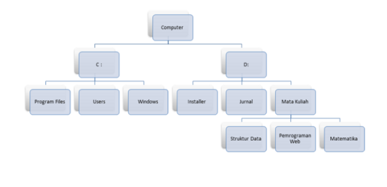

Beberapa istilah pada Tree yang harus diketahui adalah sebagai berikut :

- Node, merupakan bagian dari tree yang menyimpan informasi atau juga disebut sebagai key
- Edge, yang menghubungkan antara node yang satu dengan yang lain. Hanya ada satu edge yang masuk ke dalam node, dan satu atau lebih edge yang keluar dari suatu node
- Root, node yang terletak di paling atas, tidak ada edge yang masuk ke dalam node root ini, tapi root mempunyai satu atau lebih dari satu edge yang keluar.
- path, merupakan urutan node dari root sampai tujuan, misalkan computer --> D: --> Mata Kuliah --> Struktur Data
- children, merupakan node-node yang memiliki edge yang masuk dari node yang sama. Misalkan program files, users, dan windows merupakan children, krn memiliki edge masuk yang sama-sama berasal dari node C:
- Parent, node yang memiliki edge yang keluar dari node tersebut, misalkan node C: adalah parent dari program files, users, dan windows
- Siblings, adalah node-node yang berasal dari parent yang sama
- subtree, kumpulan dari node dan edge yang terdiri dari parent dan semua node setelah parent
- leaf node, node yang tidak memiliki edge yang keluar, node yang tidak memiliki children
- level, tingkatan dari node. Root merupakan level ke-0, semakin kebawah maka level dari node tersebut semakin besar, misalkan struktur data berada di level ke-3
- height, merupakan tinggi tree, nilai dari height ini adalah level maksimum dari tree

Subtree sendiri juga merupakan sebuah tree. Root dari subtree dihubungkan dengan edge ke root dari tree. Hal ini dapat dipandang sebagai definisi rekursif. Definisi ini dapat dilihat pada Gambar 2, sebagai berikut :

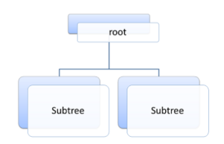

```python
class Tree:
    def __init__(self, root):
        self.key = root
        self.children = []

    # Menambah child
    def addChild(self, child_node):
        self.children.append(Tree(child_node))

    # Menampilkan root
    def getRoot(self):
        return self.key

    # Menampilkan children
    def getChildren(self):
        return self.children


# ======================
# Membuat Tree
# ======================

tree = Tree("A")

tree.addChild("B")
tree.addChild("C")
tree.addChild("D")

print("Root :", tree.getRoot())

print("Children :")
for child in tree.getChildren():
    print(child.getRoot())
```

```
Root : A
Children :
B
C
D
```

# Bianty Tree

Binary tree merupakan tree dimana setiap parent hanya memiliki dua buah atau satu node children saja. Karena didalam binary tree terdiri node dimana setiap node memiliki informasi mengenai nilai node dan edge (method untuk menambahkan node baru pada tree), maka tree ataupun binary tree ini akan lebih mudah diimplementasikan dengan menggunakan tipe data class.

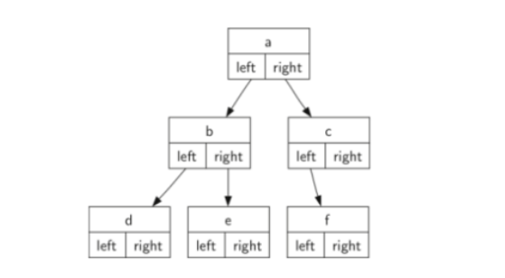

```python
class BinaryTree:
    def __init__(self, root):
        self.key = root
        self.leftChild = None
        self.rightChild = None

    # Menambah child kiri
    def insertLeft(self, new_node):
        if self.leftChild == None:
            self.leftChild = BinaryTree(new_node)
        else:
            t = BinaryTree(new_node)
            t.leftChild = self.leftChild
            self.leftChild = t

    # Menambah child kanan
    def insertRight(self, new_node):
        if self.rightChild == None:
            self.rightChild = BinaryTree(new_node)
        else:
            t = BinaryTree(new_node)
            t.rightChild = self.rightChild
            self.rightChild = t

    # Mengambil child kiri
    def getLeftChild(self):
        return self.leftChild

    # Mengambil child kanan
    def getRightChild(self):
        return self.rightChild

    # Mengambil nilai root
    def getRootVal(self):
        return self.key


# ======================
# Membuat Binary Tree
# ======================

tree = BinaryTree("A")

tree.insertLeft("B")
tree.insertRight("C")

print("Root :", tree.getRootVal())
print("Left Child :", tree.getLeftChild().getRootVal())
print("Right Child :", tree.getRightChild().getRootVal())
```

```
Root : A
Left Child : B
Right Child : C
```

# Parsing Binary Tree

Persamaan Matematika harus dipecah menjadi list token agar dapat dibuat menjadi parse tree. Token-token untuk persamaan Matematika tersebut antara lain:

- Kurung buka, kurung buka ini menandakan ekspressi baru yang akan dioperasi, oleh karena itu perlu dibuat subtree baru untuk menyelesaikan ekspressi baru ini
- kurung tutup, kurung tutup ini menandakan akhir dari ekspressi matematika
- operand, operand ini yang akan jadi leaf node dan children dari operator
- operator, operator merupakan parent dan punya left maupun right child

Berikut algoritma untuk membuat parse tree ekspressi matematika:

1. Jika current token adalah kurung buka, '(' , tambahkan node baru sebagai left child dari current Node dan jadikan node baru ini sebagai current node
2. jika current token adalah operator, set nilai key dari current node dengan operator tersebut. Tambahkan node baru sebagai right child dari current node, jadikan right child ini sebagai current node
3. jika current token adalah operand, maka set nilai key dari current node dengan operand tersebut dan jadikan parent dari node tersebut menjadi current node
4. jika current token adalah kurung tutup, ')', maka kembali ke parent dari current node

```python
import operator

# =========================
# STACK
# =========================

def stack():
    s = []
    return s

def push(s, data):
    s.append(data)

def pop(s):
    data = s.pop()
    return data

def peek(s):
    return s[len(s)-1]

def isEmpty(s):
    return s == []

def size(s):
    return len(s)


# =========================
# BINARY TREE
# =========================

class BinaryTree:

    def __init__(self, root):
        self.key = root
        self.leftChild = None
        self.rightChild = None

    def insertLeft(self, new_node):

        if self.leftChild == None:
            self.leftChild = BinaryTree(new_node)

        else:
            t = BinaryTree(new_node)
            t.leftChild = self.leftChild
            self.leftChild = t

    def insertRight(self, new_node):

        if self.rightChild == None:
            self.rightChild = BinaryTree(new_node)

        else:
            t = BinaryTree(new_node)
            t.rightChild = self.rightChild
            self.rightChild = t

    def getLeftChild(self):
        return self.leftChild

    def getRightChild(self):
        return self.rightChild

    def setRootVal(self, obj):
        self.key = obj

    def getRootVal(self):
        return self.key


# =========================
# BUILD PARSE TREE
# =========================

def buildParseTree(mathExp):

    tokenList = mathExp.split()

    parentStack = stack()

    expTree = BinaryTree(' ')

    push(parentStack, expTree)

    currentTree = expTree

    print("Token :", tokenList)

    for i in tokenList:

        # Kurung buka
        if i == '(':

            print("if 1", i)

            currentTree.insertLeft(' ')

            push(parentStack, currentTree)

            currentTree = currentTree.getLeftChild()

        # Operand / angka
        elif i not in ['+', '-', '*', '/', ')']:

            print("if 2", i)

            currentTree.setRootVal(int(i))

            parent = pop(parentStack)

            currentTree = parent

        # Operator
        elif i in ['+', '-', '*', '/']:

            print("if 3", i)

            currentTree.setRootVal(i)

            currentTree.insertRight(' ')

            push(parentStack, currentTree)

            currentTree = currentTree.getRightChild()

        # Kurung tutup
        elif i == ')':

            currentTree = pop(parentStack)

        else:
            raise ValueError

    return expTree


# =========================
# EVALUATE TREE
# =========================

def evaluate(parse_tree):

    opers = {
        '+': operator.add,
        '-': operator.sub,
        '*': operator.mul,
        '/': operator.truediv
    }

    left = parse_tree.getLeftChild()
    right = parse_tree.getRightChild()

    # Jika memiliki child kiri dan kanan
    if left and right:

        fn = opers[parse_tree.key]

        return fn(evaluate(left), evaluate(right))

    # Leaf node
    else:
        return parse_tree.key


# =========================
# MENJALANKAN PROGRAM
# =========================

pt = buildParseTree('( 3 + ( 4 * 5 ) )')

print("\nRoot :", pt.getRootVal())

print("Left Child :", pt.getLeftChild().getRootVal())

hasil = evaluate(pt)

print("Hasil =", hasil)
```

```
Token : ['(', '3', '+', '(', '4', '*', '5', ')', ')']
if 1 (
if 2 3
if 3 +
if 1 (
if 2 4
if 3 *
if 2 5

Root : +
Left Child : 3
Hasil = 23
```